## Informações Relevantes

Usaremos algumas bases de dados reais para realização dessa prova. Por conta disso, o tempo de resolução será extendido, visto que algumas dessas bases possuem mais de 50 MB, o que pode ocasionar demora no *download*.

Faça o *download* dos seguintes conjuntos de dados:

1. [Salário de Magistrados](https://drive.google.com/u/0/uc?id=1FCdmXKf35dTtmnZQ1XhQPl7sF1MxX7WV&export=download);
2. [Cursos e notas de corte do PROUNI 2018](https://drive.google.com/u/0/uc?id=1lnqYHylEWT8cN6vPZ-NRR8KfFAPNq43r&export=download)
3. [Peixes do Rio Madeira](https://github.com/icaro-freire/dados_csv/blob/main/dados/csv/peixes_rio_madeira.csv)

O uso do *software* `R` é suficiente, mas não necessário. Ou seja, você pode usar qualquer outro *software* que estiver mais familiarizado, todavia, as dicas que serão dadas em algumas questões abaixo, serão voltadas para os usuários do `R`.

## Identificação

**Aluno:** Possíveis Soluções  
**Data:** (15/ 12/ 2022)

## Questões (Soluções)

```r
# importe os dados aqui (read_csv)
## importando os dados do "Peixes do Rio Madeira"
peixes <- readr::read_csv("dados/peixes_rio_madeira.csv")

## importando os dados dos salários dos magistrados
salarios <- readr::read_csv("dados/contracheque.csv")

## importando os dados do Prouni
notas_cursos <- readr::read_csv("dados/cursos-prouni.csv")
```

### I. Sobre o *dataset* `peixes_rio_madeira.csv`

**Questão 01.** Considerando a variável `ordem`, responda:

1. Faça uma distribuição de frequência da variável `ordem`, ordenando os valores numéricos de forma crescente.
2. Qual `ordem` de peixe foi a mais identificada? Quantas foram as observações?
3. Quantos não foram identificados na variável `ordem`?
4. Faça um gráfico de barras para representar a variável ordem, nesse *dataset*.

**Solução** **a)** Obviamente, existem algumas formas de fazermos esse item. Vou usar a que relaciona os pacotes do tidyverse. A ideia, basicamente, é: após agruparmos o conjunto de dados pela variável `ordem` (`group_by(ordem)`); selecionarmos apenas essa variável (`select(ordem)`); contarmos a quantidades nos grupos (`count()`); e, por fim, ordená-los (`arrange()`). Como denotei meu conjunto de dados por `peixes`, o seguinte conjunto de códigos responde esse item:

```r
peixes |>
  dplyr::group_by(ordem) |>
  dplyr::select(ordem) |>
  dplyr::count() |>
  dplyr::arrange(n)
```

| ordem | n |
| --- | --- |
| Lepidosireniformes | 2 |
| Pleuronectiformes | 2 |
| Beloniformes | 5 |
| Não identificado | 17 |
| Myliobatiformes | 41 |
| Osteoglossiformes | 433 |
| Gymnotiformes | 693 |
| Acanthuriformes | 1602 |
| Cichliformes | 1947 |
| Clupeiformes | 2821 |

[output cut: 2 more lines]

**b)** Observando a Tabela de Frequência, a ordem de peixes mais identificada foi a *Characiformes*, com 64356 observações.

**c)** Pela Tabela de Frequência, 17 peixes não foram identificados na variável ordem.

**d)** Aproveitando a sequência de comandos que usamos para produzir a Tabela de Frequência do item a), vamos usar o `ggplot2` para produzir o gráfico em questão (`geom_col()`). Não usamos cores nas barras por acharmos redundante, mas não há impedimento nessa questão. A sequência abaixo responde ao item (note que a ordenação foi realizada usando o pacote `forcats`).

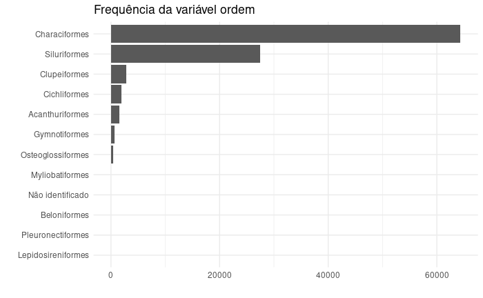

```r
peixes |>
  dplyr::group_by(ordem) |>
  dplyr::select(ordem) |>
  dplyr::count() |>
  ggplot2::ggplot() +
  ggplot2::aes(x = n, y = forcats::fct_reorder(ordem, n)) +
  ggplot2::geom_col() +
  ggplot2::theme_minimal() +
  ggplot2::labs(
    x = "",
    y = "",
    title = "Frequência da variável ordem"
  )
```

**Questão 02.** Dentre os peixes que foram coletados da bacia do “Rio Guaporé”, após a seleção da `ordem` e do `peso_g`, bem como a eliminação dos elementos não identificados; deseja-se comparar qual das ordens é a mais **homogênea**, no que se refere ao seu peso. Para isso, é necessário comparar a variabilidade do `peso_g` em relação à média. Se a média é igual em cada ordem, usamos o **desvio padrão**. Todavia, se a média em cada ordem é diferente, precisamos padronizar essa medida; e, nesse caso, usamos o **coeficiente de variação** (cv), em porcentagem. Quanto menor a porcentagem do `cv`, mais homogênea é a distribuição do `peso_g`. Define-se:
$$\text{cv} = \frac{\text{desvio padrão}}{média}
\cdot 100$$

1. Qual medida de variabilidade é mais adequada para essa situação?
2. Determine qual das ordens dos peixes da bacia do Rio Guaporé possui distribuição de peso mais homogênea.

**Solução.** **a)** A própria questão estabelece alguns parâmetros para que você chegue ao resultado desejado: agrupar pela variável `ordem` (`group_by(ordem)`); filtrar pela bacia do Rio Guaporé (`filter(bacia == "Rio Guaporé")`); selecionar a `ordem` e o `peso_g` (`select(ordem, peso_g)`); e, eliminar os elementos faltantes (os famosos “NA” – `drop_na()`). Depois disso, precisamos encontrar a média do peso (em gramas) de cada grupo. Se a média é a mesma, usamos o *desvio padrão*; caso contrário, usamos o *coeficiente de variação*. Sumarizar essas médias é simples, se agruparmos pela `ordem` e usarmos a função `summarise(media_peso = mean(peso_g))`, onde a variável “media_peso” é o que desejamos em cada grupo, e `mean(peso_g)` á como faremos esse cálculo. Veja os comando e o resultado abaixo:

```r
peixes |>
  dplyr::group_by(ordem) |>
  dplyr::filter(bacia == "Rio Guaporé") |>
  dplyr::select(ordem, peso_g) |>
  tidyr::drop_na() |>
  dplyr::summarise(
    media_peso = mean(peso_g)
  )
```

| ordem | media_peso |
| --- | --- |
| Acanthuriformes | 198.00000 |
| Characiformes | 65.84589 |
| Cichliformes | 178.80000 |
| Clupeiformes | 300.14815 |
| Gymnotiformes | 80.61111 |
| Siluriformes | 92.32534 |

Note que, como as médias foram (bem) diferentes em cada grupo, para compará-los é necessário uma padronização. Portanto, a medida de variabilidade mais adequada para essa situação é o *coeficiente de variação*.

**b)** Para analisarmos a distribuição de peixes “mais homogênea”, precisamos encontrar qual possui a *menor* porcentagem do coeficiente de variação. Portanto, precisamos construir uma expressão que calcule o `cv` em cada grupo da variável `ordem`. Pela fórmula, precisamos da “média do peso” e do “desvio padrão”. Lembrem-se que esses cálculos devem ser colocados na função `summarise`. Veja um possível código e seu resultado:

```r
peixes |>
  dplyr::group_by(ordem) |>
  dplyr::filter(bacia == "Rio Guaporé") |>
  dplyr::select(ordem, peso_g) |>
  tidyr::drop_na() |>
  dplyr::summarise(
    media_peso = mean(peso_g),
    desvio_p   = sd(peso_g),
    cv         = (desvio_p/ media_peso)*100
  ) |>
  dplyr::arrange(cv)
```

| ordem | media_peso | desvio_p | cv |
| --- | --- | --- | --- |
| Clupeiformes | 300.14815 | 234.82886 | 78.23765 |
| Gymnotiformes | 80.61111 | 79.83779 | 99.04068 |
| Acanthuriformes | 198.00000 | 249.60168 | 126.06146 |
| Cichliformes | 178.80000 | 242.39976 | 135.57033 |
| Characiformes | 65.84589 | 106.35040 | 161.51411 |
| Siluriformes | 92.32534 | 206.16689 | 223.30477 |

Como o menor *cv* foi de 78.23 aproximadamente, a ordem associada a ele é a mais homogênea. Ou seja, a ordem *Clupeiformes*.

**Questão 03.** No que se refere à variável `sexo`, recodifique-a (coloque o nomo nome como `sexo_recode`) para que você possa filtrar apenas os sexos “Macho” e “Fêmea”, depois responda:

1. Qual o aumento, em porcentagem, devemos dar à quantidade de machos para que possua a mesma quantidade referente às fêmeas?
2. Selecione as variáveis `peso_g` e `sexo_recode`, dentre os peixes identificados por “Macho” e “Fêmea”, qual o sexo do peixe com maior peso?
3. Faça um gráfico que represente de forma adequada a quantidade de machos e fêmeas, facetando tal gráfico na variável `bacia`.

**Solução.** Para que possamos recodificar corretamente às variáveis, precisamos saber quais são as diferentes denomonações existentes. Para isso, vamos usar a função `distinct()`:

```r
peixes |>
  dplyr::distinct(sexo)
```

| sexo |
| --- |
| Fêmea |
| Macho |
| Não coletado |
| fêmea |

Note que, para nossos fins, “Fêmea” e “fêmea” serão indistintos; além de não considerarmos o “Não coletado”. Assim, recodificando, e filtrando o que se pede, temos (atribuimos essas mudanças à variável `peixes_recode`):

```r
peixes_recode <- peixes |>
  dplyr::mutate(
    sexo_recode = dplyr::recode(
      sexo,
      "Fêmea" = "Fêmea",
      "Macho" = "Macho",
      "fêmea" = "Fêmea"
    )
  ) |>
  dplyr::filter(sexo_recode == "Macho" | sexo_recode == "Fêmea")
peixes_recode
```

| id | tipo_campanha | campanha | data | mes | ano | ciclo_hidrologico | bacia | ambiente | local | ponto | especie | genero | familia | ordem | nome_comum | cp_cm | peso_g | sexo | estadio_de_maturacao | habito_alimentar | sexo_recode |
| --- | --- | --- | --- | --- | --- | --- | --- | --- | --- | --- | --- | --- | --- | --- | --- | --- | --- | --- | --- | --- | --- |
| 1 | Mensal | Mensal 1 | 2010-05-03 | 5 | 2010 | Vazante | Rio Madeira | Tributário | 1 | Tribut 1 | Auchenipterichthys thoracatus | Auchenipterichthys | Auchenipteridae | Siluriformes | Cangati/Cachorro-de-padre | 12.0 | 35.0 | Fêmea | Imaturo | Onívoro | Fêmea |
| 2 | Mensal | Mensal 1 | 2010-05-03 | 5 | 2010 | Vazante | Rio Madeira | Tributário | 1 | Tribut 1 | Auchenipterichthys thoracatus | Auchenipterichthys | Auchenipteridae | Siluriformes | Cangati/Cachorro-de-padre | 11.5 | 35.0 | Macho | Imaturo | Onívoro | Macho |
| 3 | Mensal | Mensal 1 | 2010-05-03 | 5 | 2010 | Vazante | Rio Madeira | Tributário | 1 | Tribut 1 | Auchenipterichthys thoracatus | Auchenipterichthys | Auchenipteridae | Siluriformes | Cangati/Cachorro-de-padre | 11.0 | 25.0 | Fêmea | Imaturo | Onívoro | Fêmea |
| 4 | Mensal | Mensal 1 | 2010-05-03 | 5 | 2010 | Vazante | Rio Madeira | Tributário | 1 | Tribut 1 | Hydrolycus armatus | Hydrolycus | Cynodontidae | Characiformes | Cachorra | 26.5 | 265.0 | Fêmea | Repouso | Carnívoro | Fêmea |
| 10 | Mensal | Mensal 1 | 2010-05-03 | 5 | 2010 | Vazante | Rio Madeira | Tributário | 3 | Tribut 3 | Hemiodus unimaculatus | Hemiodus | Hemiodontidae | Characiformes | Orana | 21.0 | 250.0 | Fêmea | Repouso | Detritívoro | Fêmea |
| 11 | Mensal | Mensal 1 | 2010-05-03 | 5 | 2010 | Vazante | Rio Madeira | Tributário | 3 | Tribut 3 | Rhaphiodon vulpinus | Rhaphiodon | Cynodontidae | Characiformes | Peixe-cachorro | 38.0 | 465.0 | Macho | Repouso | Carnívoro | Macho |
| 13 | Mensal | Mensal 1 | 2010-05-03 | 5 | 2010 | Vazante | Rio Madeira | Tributário | 4 | Tribut 4 | Cynodon gibbus | Cynodon | Cynodontidae | Characiformes | Cachorra | 23.5 | 190.0 | Fêmea | Imaturo | Carnívoro | Fêmea |
| 14 | Mensal | Mensal 1 | 2010-05-03 | 5 | 2010 | Vazante | Rio Madeira | Tributário | 4 | Tribut 4 | Rhaphiodon vulpinus | Rhaphiodon | Cynodontidae | Characiformes | Peixe-cachorro | 32.5 | 295.0 | Fêmea | Repouso | Carnívoro | Fêmea |
| 15 | Mensal | Mensal 1 | 2010-05-03 | 5 | 2010 | Vazante | Rio Madeira | Tributário | 5 | Tribut 5 | Acestrorhynchus falcirostris | Acestrorhynchus | Acestrorhynchidae | Characiformes | Cachorra/Uéia | 37.0 | 565.0 | Macho | Repouso | Carnívoro | Macho |
| 16 | Mensal | Mensal 1 | 2010-05-03 | 5 | 2010 | Vazante | Rio Madeira | Tributário | 5 | Tribut 5 | Auchenipterichthys thoracatus | Auchenipterichthys | Auchenipteridae | Siluriformes | Cangati/Cachorro-de-padre | 11.0 | 30.0 | Macho | Imaturo | Onívoro | Macho |

[output cut: 990 more lines]

Feito isso, podemos responder aos itens.

**a)** Para respondermos essa questão, é necessário contarmos a quanditade de Machos e Fêmeas. Podemos fazer isso com os comendos:

```r
peixes_recode |>
  dplyr::count(sexo_recode)
```

| sexo_recode | n |
| --- | --- |
| Fêmea | 28331 |
| Macho | 21469 |

Sendo assim, se $p$ é a porcentagem que estamos procurando, temos:
$$21469\cdot p + 21469 = 28331$$
Daí, encontramos $p=0.3196$. Ou seja, precisamos aumentar em, aproximadamente, $32\%$ à quantidade de machos para que possua a mesma quantidade referente às fêmeas.

**b)** Obviamente, precisamos usar a função `select()` e, depois, `arrange()`. Usamos a função `head()` para selecionar as primeiras linhas:

```r
peixes_recode |>
  dplyr::select(peso_g, sexo_recode) |>
  dplyr::arrange(desc(peso_g)) |>
  head()
```

| peso_g | sexo_recode |
| --- | --- |
| 14600 | Fêmea |
| 12405 | Fêmea |
| 11600 | Fêmea |
| 11230 | Fêmea |
| 10770 | Fêmea |
| 10545 | Fêmea |

Claramente, uma *Fêmea* possui o maior peso dentre esses peixes ($14.6$ kg).

**c)** Primeiro vamos agrupar pela variável `bacia`; depois, contar a quandidade dos peixes pelo sexo recodificado. O sexo será a variável do eixo x e a quantidade $n$ (frequência absoluta) a do eixo y. Após isso, basta escolher a geometria do gráfico como `col` e facetar pela bacia. O código abaixo produz o gráfico desejado:

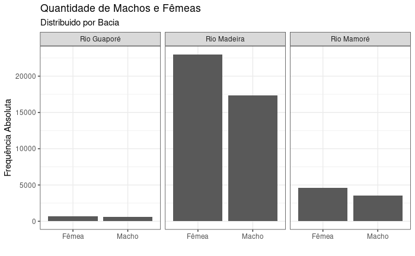

```r
peixes_recode |>
  dplyr::group_by(bacia) |>
  dplyr::count(sexo_recode) |>
  ggplot2::ggplot() +
  ggplot2::aes(x = sexo_recode, y = n) +
  ggplot2::geom_col() +
  ggplot2::facet_grid(.~bacia) +
  ggplot2::ggtitle(
    "Quantidade de Machos e Fêmeas", subtitle = "Distribuido por Bacia"
  ) +
  ggplot2::labs(x="", y="Frequência Absoluta") +
  ggplot2::theme_bw()
```

**Questão 04.** Faça um gráfico de pontos relacionando o peso (em kilogramas) e o comprimento (em metros), destacando a curva que melhor se adequa aos pontos, colorindo segundo a variável `ordem`. Depois, facete-o por `bacia`. Para ajudar, complete adequadamente o código abaixo (considere a variável `dados_peixes`, o conjunto de dados em questão), substituindo o símbolo “❓❓” pela variável conveniente.

```r
dados_peixe %>%
  select(ordem, peso_g, cp_cm) %>%
  ggplot() +
  aes(x=️ ❓❓/1000, y = ❓❓/100) +
  geom_point(aes(color = ❓❓), alpha = 0.5) +
  facet_grid(❓❓~.) +
  geom_smooth()
```

1. A curva que se adapta aos pontos é (praticamente) a mesma em cada bacia?
2. Qual a sua interpretação para esse fato (dica: pesquise sobre a curva de “crescimento logístico” aplicada ao crescimento de população - no caso, de peixes)?

**Solução.**

Os códigos abaixo geram o gráfico em questão:

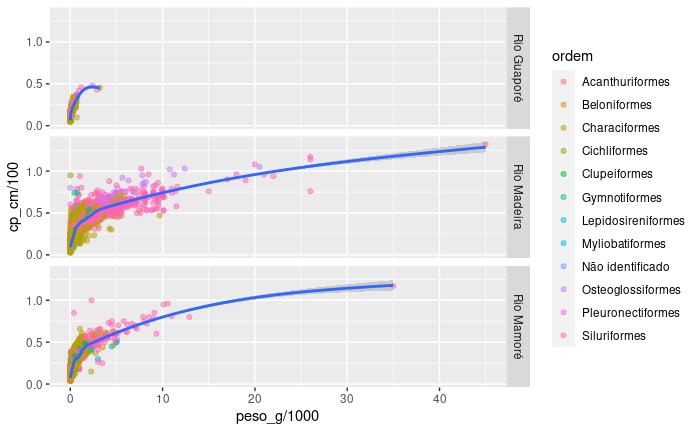

```r
peixes |>
  dplyr::group_by(bacia) |>
  dplyr::select(ordem, peso_g, cp_cm) |>
  ggplot2::ggplot() +
  ggplot2::aes(x = peso_g/1000, y = cp_cm/100) +
  ggplot2::geom_point(
    ggplot2::aes(color = ordem), alpha = 0.5
  ) +
  ggplot2::facet_grid(bacia~.) +
  ggplot2::geom_smooth()
```

**a)** Aparentemente, a curva que se adapta aos pontos é (praticamente) a mesma em cada bacia.

**b)** ITEM ANULADO!

### II. Sobre o *dataset* `contracheque.csv`

Antes de iniciarmos a análise do *dataset* em questão, vamos conhecê-lo de forma panorâmica:

```r
salarios |> tibble::glimpse()
```

```
Rows: 161,767
Columns: 22
$ cpf                              <chr> NA, NA, NA, NA, NA, NA, NA, NA…
$ nome                             <chr> "Aldir Guimarães Passarinho Ju…
$ cargo                            <chr> "Ministro do Superior Tribunal…
$ lotacao                          <chr> "Superior Tribunal de Justiça"…
$ subsidio                         <dbl> 32074.85, 32074.85, 32074.85, …
$ direitos_pessoais                <dbl> 0.00, 3528.23, 0.00, 3528.23, …
$ indenizacoes                     <dbl> 0.00, 884.00, 0.00, 884.00, 52…
$ direitos_eventuais               <dbl> 0, 0, 0, 0, 0, 0, 0, 0, 0, 0, …
$ total_de_rendimentos             <dbl> 32074.85, 36487.08, 32074.85, …
$ previdencia_publica              <dbl> 2907.19, 3528.23, 2907.19, 352…
$ imposto_de_renda                 <dbl> 6628.15, 6980.96, 6628.15, 698…
$ descontos_diversos               <dbl> 0, 0, 0, 0, 0, 0, 0, 0, 0, 0, …
$ retencao_por_teto_constitucional <dbl> 0, 0, 0, 0, 0, 0, 0, 0, 0, 0, …
$ total_de_descontos               <dbl> 9535.34, 10509.19, 9535.34, 10…
$ rendimento_liquido               <dbl> 22539.51, 25977.89, 22539.51, …
$ remuneracao_do_orgao_de_origem   <dbl> 0.00, 0.00, 0.00, 0.00, 0.00, …
$ diarias                          <dbl> 0, 0, 0, 0, 0, 0, 0, 0, 0, 420…
$ url                              <chr> "http://www.cnj.jus.br/files/c…
$ tribunal                         <chr> "Superior Tribunal de Justiça"…
$ orgao                            <chr> "Superior Tribunal de Justiça"…
$ data_de_publicacao               <dttm> 2018-04-24, 2018-04-24, 2018-…
$ mesano_de_referencia             <chr> "2018-4-01", "2018-4-01", "201…
```

**Questão 05.** Qual o maior rendimento líquido registrado nesse *dataset*?

**Solução.** Existem algumas formas de respondermos essa questão. Por exemplo, podemos selecionar a variável `rendimento_liquido` e usar a função `arrange` para colocarmos em ordem decrescente os valores, como no código abaixo:

```r
salarios |>
  dplyr::select(rendimento_liquido) |>
  dplyr::arrange(desc(rendimento_liquido)) |>
  head()
```

| rendimento_liquido |
| --- |
| 7267671.8 |
| 2874516.2 |
| 683093.9 |
| 660933.6 |
| 511423.6 |
| 477756.2 |

Também poderíamos encontrar diretamente o valor, sumarizando a informação do máximo rendimento:

```r
salarios |>
  dplyr::select(rendimento_liquido) |>
  tidyr::drop_na() |>
  dplyr::summarise(
    max_salario = max(rendimento_liquido)
  )
```

| max_salario |
| --- |
| 7267672 |

Portanto, o rendimento líquido máximo é de, aproximadamente, $R\$\, 7.267.672,00$. Vou até escrever por extenso para você não pensar que errei na digitação: *sete milhões, duzentos e sessenta e sete mil, seiscentos e setenta e dois* reais.

**Questão 06.** Sabendo-se que o teto constitucional do funcionalismo público é de $$ 39.293,32 $, determine quantos magistrados receberam acima desse valor.

1. Quantos magistrados ganharam acima de $\text{R}\$ 100.000,00$ ?
2. Qual `tribunal` possui maior variabilidade?

**Solução.** Para sabermos quantos magistrados recebem acima do teto constitucional, precisamos selcionar a variável `rendimento_liquido` e, depois, filtrarmos condicionando o valor que desejamos. Por fim, realizamos a contagem com `count()`:

```r
salarios |>
  dplyr::select(rendimento_liquido) |>
  dplyr::filter(rendimento_liquido >= 39293.32) |>
  dplyr::count()
```

| n |
| --- |
| 37334 |

Logo, são $37334$ magistrados que ganham acima do teto constitucional.

**a)** Usando o raciocínio anterior, temos:

```r
salarios |>
  dplyr::select(rendimento_liquido) |>
  dplyr::filter(rendimento_liquido >= 100000) |>
  dplyr::count()
```

| n |
| --- |
| 1136 |

**b)** Para maior variabilidade, precisamos decidir se usaremos o desvio padrão ou o coeficiente de vairação. Para isso, vamos analisar a média em cada tribunal:

```r
salarios |>
  dplyr::group_by(tribunal) |>
  dplyr::summarise(
    media_salarios = mean(rendimento_liquido)
  )
```

| tribunal | media_salarios |
| --- | --- |
| Conselho da Justiça Federal | 1327.989 |
| Conselho Nacional de Justiça | 6333.494 |
| Superior Tribunal de Justiça | 28822.804 |
| Superior Tribunal Militar | 30117.813 |
| Tribunal de Justiça da Bahia | 34935.214 |
| Tribunal de Justiça da Paraíba | 26948.714 |
| Tribunal de Justiça de Alagoas | 37808.900 |
| Tribunal de Justiça de Goiás | 30591.351 |
| Tribunal de Justiça de Minas Gerais | 46560.269 |
| Tribunal de Justiça de Pernambuco | 22336.645 |

[output cut: 118 more lines]

Como há médias diferentes em cada tribunal, usaremos o coeficiente de variação; arranjando de forma decrescente esses valores e escolhendo o maior dentre eles:

```r
salarios |>
  dplyr::group_by(tribunal) |>
  dplyr::summarise(
    media_salarios = mean(rendimento_liquido),
    dp_salarios    = sd(rendimento_liquido),
    cv_salarios    = (dp_salarios/media_salarios)*100
  ) |>
  dplyr::arrange(desc(cv_salarios)) |>
  dplyr::top_n(1) |>
  dplyr::select(tribunal)
```

| tribunal |
| --- |
| Tribunal Regional do Trabalho da 7ª Região (CE) |

Portanto, o *Tribunal Regional do Trabalho da 7ª Região (CE)* é aquele que possui maior variabilidade.

### Sobre o *dataset* `cursos_prouni.csv`

Mais uma vez, é essencial analisarmos panoramicamente os dados:

```r
notas_cursos |> tibble::glimpse()
```

```
Rows: 41,447
Columns: 20
$ grau                 <chr> "Bacharelado", "Bacharelado", "Bacharelado…
$ turno                <chr> "Integral", "Noturno", "Integral", "Noturn…
$ mensalidade          <dbl> 9999.99, 9836.40, 9715.61, 9689.34, 9674.3…
$ bolsa_integral_cotas <dbl> 15, 1, 2, 3, 4, 8, 3, 4, 7, 13, 4, 5, 2, 2…
$ bolsa_integral_ampla <dbl> 14, NA, 5, 2, 1, 15, 5, 3, 5, 4, 4, 1, 9, …
$ bolsa_parcial_cotas  <dbl> NA, NA, 6, NA, 5, NA, NA, NA, NA, NA, 5, N…
$ bolsa_parcial_ampla  <dbl> NA, NA, 10, NA, 2, NA, NA, NA, NA, NA, 5, …
$ curso_id             <dbl> 7.067104e+11, 1.041912e+14, 1.002329e+12, …
$ curso_busca          <chr> "Medicina", "Enfermagem", "Medicina", "Psi…
$ cidade_busca         <chr> "Campo Grande", "Crateus", "Sao Paulo", "C…
$ uf_busca             <chr> "MS", "CE", "SP", "CE", "AC", "SP", "SP", …
$ cidade_filtro        <chr> "NTAwMjAwNDAyNzA0", "MjMwNDAxODA0MTAz", "M…
$ universidade_nome    <chr> "Universidade Anhanguera - UNIDERP", "Facu…
$ campus_nome          <chr> "CAMPO GRANDE - SEDE - Miguel Couto", "UNI…
$ campus_id            <dbl> 706710, 1041912, 1002328, 1041912, 658996,…
$ nome                 <chr> "Medicina", "Enfermagem", "Medicina", "Psi…
$ nota_integral_ampla  <dbl> 740.22, 663.36, 739.62, 651.00, 758.32, 73…
$ nota_integral_cotas  <dbl> 726.46, NA, 738.08, 652.22, 723.94, 728.86…
$ nota_parcial_ampla   <dbl> NA, NA, 738.96, NA, 734.92, NA, NA, NA, NA…
$ nota_parcial_cotas   <dbl> NA, NA, 718.64, NA, 711.26, NA, NA, NA, NA…
```

**Questão 07.** Para responder essa questão, complete adequadamente o código abaixo, referente a construção de um *boxplot* da varivável `nota_integral_ampla`, agrupadas pelo `turno` (estamos considerando a variável `dados_cursos`, como sendo o *dataset* `cursos_prouni.csv`).

```r
dados_cursos %>%
  select(❓❓ , ❓❓) %>%
  drop_na() %>%
  ggplot() +
  aes(x = ❓❓, y = ❓❓, fill = ❓❓) +
  geom_boxplot(show.legend = FALSE) +
  labs(
    title = "Comparação das notas por turno",
    x = "",
    y = ""
  ) +
  scale_fill_viridis_d() +
  theme_minimal()
```

1. Pelo gráfico, qual dos turnos possui a maior mediana das notas? Explique.
2. Qual a média e a mediana do turno identificado no item anterior?
3. Qual dos cinco turnos possui menor homegeneidade na nota integral ampla?
4. Faça um gráfico de densidade dessas notas, facetando-as nos turnos. Esse gráfico também serviria para comparar as notas por turno? Explique.

**Solução.** Completando os códigos, temos:

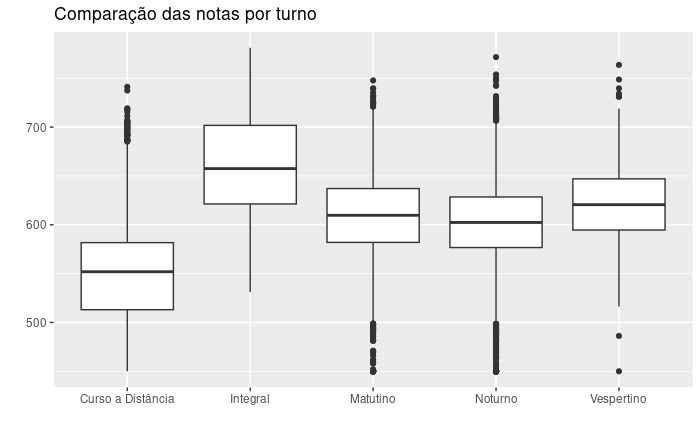

```r
notas_cursos |>
  dplyr::group_by(turno) |>
  dplyr::select(turno, nota_integral_ampla) |>
  tidyr::drop_na() |>
  ggplot2::ggplot() +
  ggplot2::aes(x = turno, nota_integral_ampla) +
  ggplot2::geom_boxplot() +
  ggplot2::labs(
    title = "Comparação das notas por turno",
    x     = "",
    y     = ""
  )
```

Agora podemos responder as questões.

**a)** O turno *Integral* possui maior mediana das notas. De fato, a linha horizontal do interior da ``caixa’’ representa o segundo quartil, ou mediana dos dados. Comparando a projeção dessa linha no eixo vertical, o turno *Integral* é o que possui maior medida.

**b)** Olhando apenas pelo gráfico não temos precisão do valor. Precisamos, então, calcular explicitamente esses valores. Para tanto, vamos sumarizar a media e a mediana; depois de ter filtrado o turno; selecionado a variável `nota_integral_ampla`; e ter retirado os elementos faltantes. O código abaixo indica o que precisamos:

```r
notas_cursos |>
  dplyr::filter(turno == "Integral") |>
  dplyr::select(nota_integral_ampla) |>
  tidyr::drop_na() |>
  dplyr::summarise(
    media_notas = mean(nota_integral_ampla),
    mediana_notas = median(nota_integral_ampla)
  )
```

| media_notas | mediana_notas |
| --- | --- |
| 663.1 | 657.5 |

Logo, a media das notas é de $663.1$ e a mediana $657.5$.

**c)** Seguindo o raciocínio das questões anteriores, precisamos comparar as médias depois de ter agrupado por turno e selecionado a variável `nota_integral_ampla` (sem os elementos faltantes). Isso é feito assim:

```r
notas_cursos |>
  dplyr::group_by(turno) |>
  dplyr::select(nota_integral_ampla) |>
  tidyr::drop_na() |>
  dplyr::summarise(
    media_notas = mean(nota_integral_ampla)
  )
```

| turno | media_notas |
| --- | --- |
| Curso a Distância | 544.7927 |
| Integral | 663.1000 |
| Matutino | 609.1443 |
| Noturno | 601.8865 |
| Vespertino | 622.0320 |

Como as médias são diferentes, usaremos como medida de variabilidade o coeficiente de variação, ordenando de forma decrescente:

```r
notas_cursos |>
  dplyr::group_by(turno) |>
  dplyr::select(nota_integral_ampla) |>
  tidyr::drop_na() |>
  dplyr::summarise(
    media_notas = mean(nota_integral_ampla),
    dp_notas    = sd(nota_integral_ampla),
    cv_notas    = (dp_notas/media_notas) * 100
  ) |>
  dplyr::arrange(desc(cv_notas))
```

| turno | media_notas | dp_notas | cv_notas |
| --- | --- | --- | --- |
| Curso a Distância | 544.7927 | 53.24330 | 9.773131 |
| Integral | 663.1000 | 57.99986 | 8.746773 |
| Matutino | 609.1443 | 43.48318 | 7.138405 |
| Noturno | 601.8865 | 41.22816 | 6.849823 |
| Vespertino | 622.0320 | 40.98488 | 6.588870 |

Logo, o turno que possui *menor* homogenedade é o que possui o *MAIOR* coeficiente de variação, a saber, “Curso a Distância”.